# Developing Defections Data

Two Early-Stage Resources

Jonathan Pinckney, Julian Fortuna, and Suhan Kacholia

2026-02-20

## Key Questions for New Data Sources

- How can these resources (and others) fit within a common conceptual framework?
- How can we design these resources to most effectively answer questions from the previous session?
- What methodological challenges should we be keeping in mind?
- How can we design these resources to most effectively pipeline findings to relevant practitioner audiences?

## What Data Resources Already Exist?

- Military and civil service defections during civil resistance campaigns (Dahl, Celestino, and Gates 2026; Chenoweth and Shay 2022)
- Loyalty/defection at the pillar of support level for some pillars in some backsliding spells (Pinckney and Trilling 2025)
- Individual-level data on authoritarian legislators/ministers including instances of defection to the opposition (del Río 2022)

## What is Missing?

- Data that tracks broader populations of regime supporters across time and contexts
- Data on a wider range of types of defections, recognizing the importance of context and subtle/quiet action
- Comparative case studies and stories that process-trace defections across cases and contexts

Cross-National Defections Data

## What is This Resource For?

- Large-*n* analysis to identify factors that predict defection cross-nationally
- Identifying key global cases of defection for process-tracing

## Scope Conditions

Every authoritarian and democratic backsliding regime in the post-Cold War era - 3400 country-years (Lührmann, Tannenberg, and Lindberg 2018; Lührmann and Lindberg 2019)

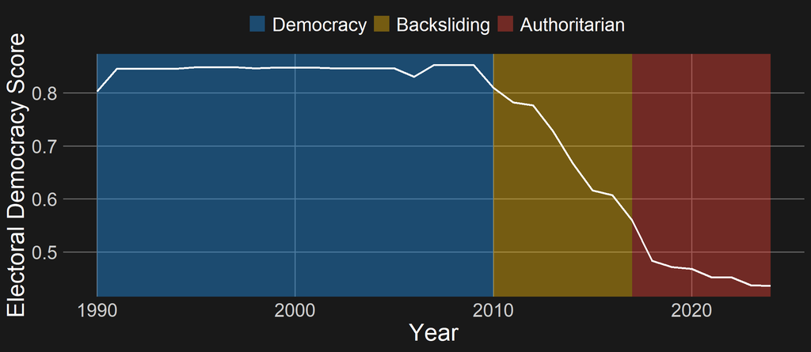

Regime Periods in Hungary 1990-2024

## Unit of Analysis

The **regime support group**-country-year

> “A group of individuals who are supportive of the existing regime, and, *if* it were to retract support would substantially increase the chance that the regime would lose power” (Knutsen et al. 2025, 5)

The *Regime Support and Opposition Groups* dataset: country expert data on whether 14 groups *support*, *oppose*, or *actively oppose* a political regime.

Variables are measured as percentage of experts who agree that the group falls into that category

| Groups |
| --- |

Aristocracy  
Landholders  
Party Elites  
Business Elites  
Bureaucracy  
Military  
Ethnic Group  
Religious Group  
Local Elites  
Urban Workers  
Urban Middle Class  
Rural Workers  
Rural Middle Class  
Foreign Government

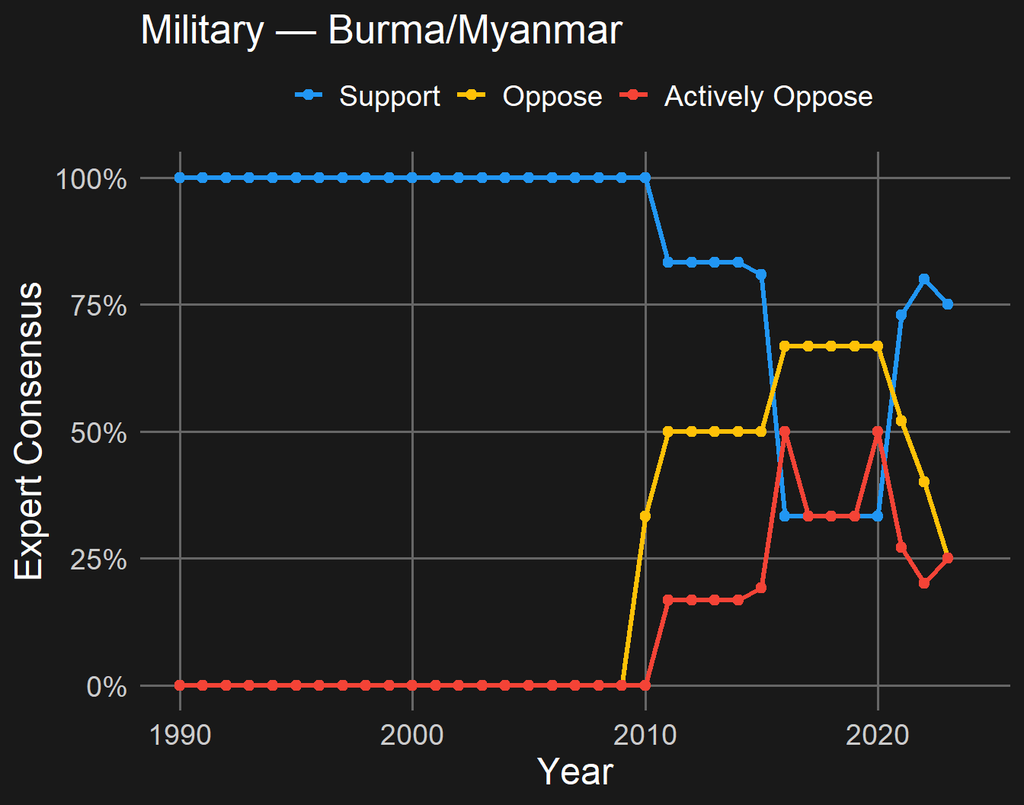

## Potential Defection Years

Country-years in which consensus on regime support was above a threshold in the prior year, and consensus on *support falls* below a threshold or *opposition rises* above a threshold in the current year.

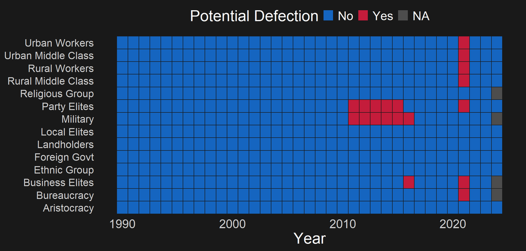

## Potential Variables

Limit to variables not readily available from existing data sources

| Variable | Question |
| --- | --- |
| group.loyalty.unity | How united is this group in its allegiance or opposition to the regime? |
| group.loyalty.intensity | What is the highest level of opposition to the regime that you observe among this group? |
| opposition.tactics | Did the opposition engage in any intentional attempts to spark defections from this group? |
| opposition.tactics.list | What specific tactics did the opposition employ to attempt to spark defections from this group? |
| defection.tactics | What specific actions did members of this support group engage in that resisted or opposed the regime in power? |
| social.connection | How dense are the social connections between this group and the opposition? |
| vignette | Is this group in this year a good candidate for a defection case study? |

## Data Collection and Coding Process

- Code variables for each *relevant* support group beginning from first year of a regime
- Carry values forward until *potential defection year*, then carry values forward until next potential defection year
- Code based on curated list of scholarly and media sources. Double-code with human RA coder and LLM-based AI agent
- Where possible, check against existing datasets to see what is being captured and what is not

## Some Preliminary Modeling!

Civil resistance campaigns are associated with more potential defections!

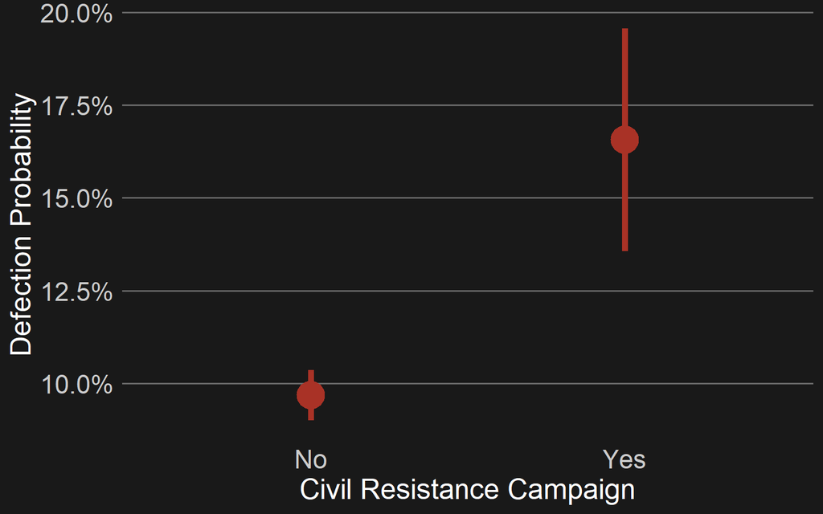

### Discussion

## A Few Major Questions for Feedback

- What are the biggest problems with this approach? What is it likely to miss?
- What variables should we include in order to test hypotheses/provide insights on the questions brought up in the second session?
- What should we be looking for in informing the *vignette* variable? What kinds of defection stories from a global context should we be flagging?

### Now over to Julian and Suhan!

## References

Chenoweth, Erica, and Christopher Wiley Shay. 2022. “Updating Nonviolent Campaigns: Introducing NAVCO 2.1.” *Journal of Peace Research* 59 (6): 876–89.

Dahl, Marianne, Mauricio Rivera Celestino, and Scott Gates. 2026. “Disaggregating Defection: Dissent Campaign Strategies and Security Force Disloyalty.” *Journal of Conflict Resolution* 70 (1): 170–95. https://doi.org/10.1177/00220027251348389.

del Río, Adrián. 2022. “Strategic Uncertainty and Elite Defections in Electoral Autocracies: A Cross-National Analysis.” *Comparative Political Studies* 55 (13): 2250–82. https://doi.org/10.1177/00104140221074273.

Knutsen, Carl Henrik, Sirianne Dahlum, Magnus B. Rasmussen, and Tore Wig. 2025. “Behind the Throne: Regime Support Coalitions Around the World, 1789-2020.” *British Journal of Political Science* 55: e37.

Lührmann, Anna, and Staffan I. Lindberg. 2019. “A Third Wave of Autocratization Is Here: What Is New about It?” *Democratization* 26 (7): 1095–1113.

Lührmann, Anna, Marcus Tannenberg, and Staffan I. Lindberg. 2018. “Regimes of the World (RoW): Opening New Avenues for the Comparative Study of Political Regimes.” *Politics and Governance* 6 (1): 60–77.

Pinckney, Jonathan, and Claire Trilling. 2025. “Breaking Down Pillars of Support for Democratic Backsliding.” *Mobilization: An International Quarterly* 30 (2): 171–88.